# Altbier

BB; KS -

February 20, 2017

Data collected by Roy Daniels (Designing Great Beers) about German breweries in Dusseldorf:

- OG = 1.047
- FG = 1.008 - 1.010
- BU = 33-48, but closer to 33
- BU:GU = [min .56, avg .70, max 1.00]

Style notes from Daniels:

- High attentuation, similar to Kolsch
- Hop bitterness only, no hop aroma, very little hop flavor
- Deep, copper color achieved through specialty malts, namely black malt

Note: Diebels Alt uses 10% munich, 90% pilsener

2nd round NHC contestants all used crystal malts but if you want to be authentic, try it without them. Average grain bill from NHC below. Note: very similar to recipe found in Brewing Classic Styles, which we’ve used as a reference before.

- Pilsen - 75%
- Munich - 19%
- CaraMunich - 5%
- Carafa - 1%

## Recipe

| Recipe | Style | Date | OG | FG |
| --- | --- | --- | --- | --- |
| Altbier1 | Altbier | 02.20.2017 | 1.051 | 1.008 |

## Fermentables

| Recipe | Ingredients | Lbs |
| --- | --- | --- |
| Altbier1 | Pilzen 1.7 L | 7.75 |
| Altbier1 | Munich Dark 15 L | 2.00 |
| Altbier1 | Carafa II 430 L | 0.15 |

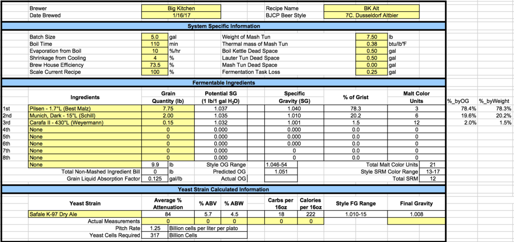

Recipe_Fermentables_Spreadsheet

# Hops

Spalt hops is what all the commercial brewers use in Dusseldorf and Daniels highly recommends it for the style. We have used it before in a Kolsch and I loved it.

| Recipe | Hop | Weight | Boil_Time | IBU |
| --- | --- | --- | --- | --- |
| Altbier1 | Spalt | 4.35 | 60 | 34 |

# Mash

Mash around 145-149 to achieve a high attenuation.

| Recipe | Mash_Thickness | Sacc_Rest | Mash_Duration | Strike_Water_Temp | Mash_Vol | Sparge_Vol |
| --- | --- | --- | --- | --- | --- | --- |
| Altbier1 | 1.68 | 147 | 90 | 156 | 4.16 | 4.91 |

# Yeast

| Recipe | Yeast_Strain | Attenuation | Initial_Cell_Count_Billions | Pitched_Cells_Billions | Liters_For_Starter | Time_For_Starter |
| --- | --- | --- | --- | --- | --- | --- |
| Altbier1 | Safale K-97 Dry Ale | 84 | NA | 317 | NA | NA |

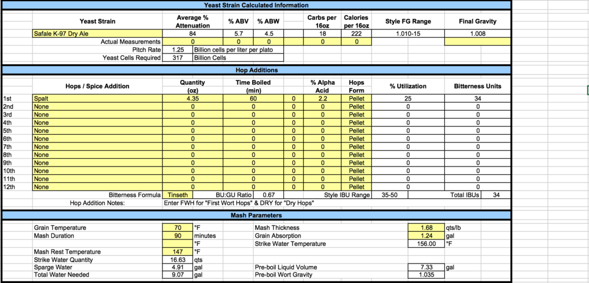

# Fermentation

We are a bit rushed for time, so we are gonna try to keep fermentation within 5-6 weeks.

| Recipe | Temp1 | Days1 | Temp2 | Days2 | Temp3 | Days3 | Temp4 | Days4 | Temp5 | Days5 | Temp6 | Days6 | Temp7 | Days7 | Temp8 | Days8 | Temp9 | Days9 | Temp10 | Days10 | Temp11 | Days11 | Temp12 | Days12 |
| --- | --- | --- | --- | --- | --- | --- | --- | --- | --- | --- | --- | --- | --- | --- | --- | --- | --- | --- | --- | --- | --- | --- | --- | --- |
| Altbier1 | 64 | 7 | 72 | 1 | 64 | 6 | 60 | 1 | 55 | 1 | 50 | 1 | 44 | 10 | 50 | 1 | 55 | 1 | 60 | 1 | 64 | 1 | 68 | 1 |

Note: Bottle at room temp for 2 weeks and serve

# Water Chemistry

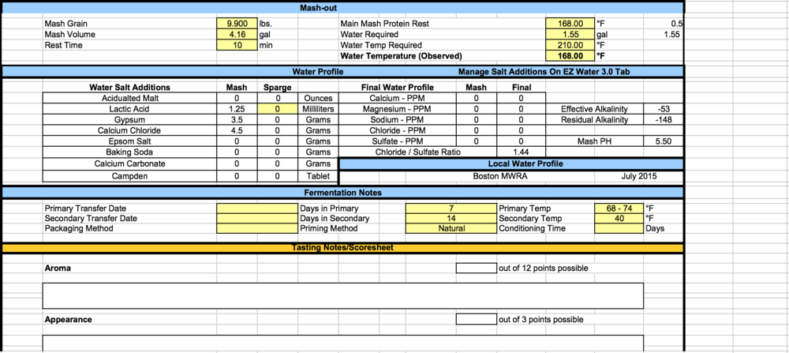